# HBP Main Analyses 1 and 3

Rujia Liu and Thomas E. Love

2017-12-06

```r
library(knitr); library(lme4); library(broom)
library(magrittr); library(tidyverse)

## Global options
opts_chunk$set(comment=NA)
opts_knit$set(width=80)
```

```r
theme_bh <- theme_bw() +
    theme(text = element_text(face="bold", size = 13),
          plot.title=element_text(face="bold", colour=bh.rasp),
          plot.subtitle=element_text(face="bold"),
          strip.text = element_text(face="bold"),
          strip.background = element_rect(fill="ivory", colour="black"),
          axis.title.x=element_text(face="bold"),
          axis.title.y=element_text(face="bold"))
```

# 1 Data Setup

The `hbpdat` file contains the most recent master data.

```r
hbpraw <- read.csv("master htn 2017-12-05.csv") %>% tbl_df

hbpdat <- hbpraw %>%
  filter(CATVAR %in% c("Overall", "INSUR", "RACE", "GENDER",
                       "INCOMECAT", "HSGRADCAT", "LANG", "LOCATION"))

hbpdat$time <- 2006.5 + (hbpdat$REPORT/2)
hbpdat$years <- hbpdat$time - 2012.5 # years since 2012-13 report
hbpdat$incomeK <- hbpdat$INC_MEAN/1000

hbpdat$category <- fct_recode(hbpdat$CATVAR,
                              "Insurance" = "INSUR",
                             "Place of Residence" = "LOCATION",
                             "Education" = "HSGRADCAT",
                             "Sex" = "GENDER",
                             "Race-Ethnicity" = "RACE",
                             "Language" = "LANG",
                             "Income" = "INCOMECAT")

hbpdat$subgroup <- fct_recode(hbpdat$CATTXT,
     "African-Am." = "african-aO",
     "Cleveland" = "CLEVE",
     "Commercial" = "COMMERCIAL",
     "Cuyahoga Suburbs" = "CUYA NOT CLEVE",
     "Prefer English" = "ENGLISH",
     "Female" = "FEMALE",
     "High Education" = "HIGH EDUC",
     "High Income" = "HIGH INCOME",
     "Hispanic/Latino" = "hispanicO",
     "Low Education" = "LOW EDUC",
     "Low Income" = "LOW INCOME",
     "Male" = "MALE",
     "Medicaid" = "MEDICAID",
     "Medicare" = "MEDICARE",
     "Middle Education" = "MIDDLE EDUC",
     "Middle Income" = "MIDDLE INCOME",
     "Outside Cuyahoga" = "OUTSIDE CUYA",
     "ALL PATIENTS" = "OVERALL",
     "Prefer Spanish" = "SPANISH",
     "Uninsured" = "UNINSURED",
     "White" = "whiteO")
```

## 1.1 Analytic Decisions Implemented in this Document

These issues will need to be discussed on 2017-12-13.

1. Include data from 2012-13 through 2016-17.
2. Include data from all practices at all systems.
3. Include data from a practice if it has at least 50 HBP subjects.
4. Include data from a practice in subgroup analyses only if it has at least 50 HBP subjects in that subgroup.
5. Covariate adjustment is time-varying, rather than baseline only.
6. Clustering by practice, but no adjustment for practice’s baseline level of BP < 140/90.
7. Time is measured in calendar time, so this is not a “Time 0” analysis.
8. Fit linear, rather than piecewise linear or quadratic or spline models.

# 2 Mixed Effects Models for BP Control (Analysis 1)

The goal here is to describe overall change in BP < 140/90 from 2012-13 through 2016-17 across the region, first in an unadjusted analysis, then in a covariate-adjusted analysis. We could present separate estimates overall and within insurance groups.

## 2.1 Across All Patients (Overall subgroup)

### 2.1.1 Select out the overall practice data from 2012-13 and forward, only those practices with at least 50 patients.

```r
hbp_overall <- hbpdat %>%
  filter(PRACTICE != "System") %>%
  filter(PRACTICE != "Region") %>%
  filter(SYSTEM != "SNET") %>%
  filter(time >= 2012.5) %>%
  filter(HBPPTS > 49) %>%
  filter(ORDER == 100) %>%
  select(REPORT, time, years, SYSTEM, PRACTICE, PRACCODE, ORDER, category, subgroup,
         HBPPTS, BPLT14090, BMILT30, AGE_MEAN, FEMALE, incomeK, ED_MEAN, WHITE,
         MEDICARE, COMMERCIAL, MEDICAID, UNINSURED, ENGLISH, SPANISH,
         CLEVE, CUYNOTCLE, NOTCUYA ) %>%
  droplevels()
```

### 2.1.2 Descriptive Summaries (counting only practices with at least 50 HBP patients)

```r
hbp_overall <- hbp_overall %>%
  mutate(n_BPLT14090 = round(HBPPTS * BPLT14090 / 100, 0))

tab_d_overall <- hbp_overall %>% group_by(time, years) %>%
  summarize(Practices = n(), Patients = sum(HBPPTS),
            Pct_below_14090 = 100*sum(n_BPLT14090)/sum(HBPPTS))

kable(tab_d_overall)
```

| time | years | Practices | Patients | Pct_below_14090 |
| --- | --- | --- | --- | --- |
| 2012.5 | 0.0 | 55 | 135359 | 68.94924 |
| 2013.0 | 0.5 | 51 | 134379 | 68.64763 |
| 2013.5 | 1.0 | 52 | 137560 | 69.56964 |
| 2014.0 | 1.5 | 68 | 155036 | 67.93003 |
| 2014.5 | 2.0 | 66 | 153510 | 68.55905 |
| 2015.0 | 2.5 | 72 | 179076 | 67.17874 |
| 2015.5 | 3.0 | 74 | 182107 | 71.01979 |
| 2016.0 | 3.5 | 78 | 183698 | 71.98010 |
| 2016.5 | 4.0 | 80 | 194742 | 73.78583 |

### 2.1.3 Figure 1. Achievement of BP < 140/90, Region-wide, All Patients

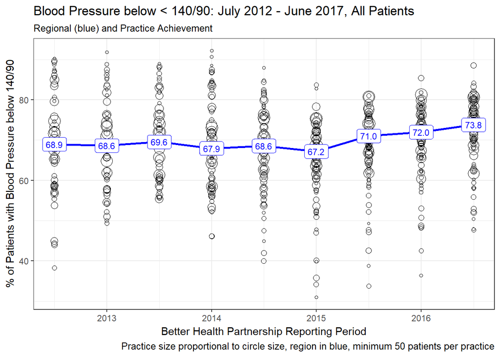

```r
ggplot(data = hbp_overall, aes(x = time, y = BPLT14090, size = HBPPTS)) +
  geom_point(pch = 1) +
  guides(size = FALSE) +
  geom_line(data = tab_d_overall, aes(x = time, y = Pct_below_14090),
            col = "blue", size = 1) +
  geom_label(data = tab_d_overall, aes(x = time, y = Pct_below_14090,
                                  label = decim(Pct_below_14090,1)),
             col = "blue", size = 3) +
  theme_bw() +
  labs(x = "Better Health Partnership Reporting Period",
       y = "% of Patients with Blood Pressure below 140/90",
       title = "Blood Pressure below < 140/90: July 2012 - June 2017, All Patients",
       subtitle = "Regional (blue) and Practice Achievement",
       caption = "Practice size proportional to circle size, region in blue, minimum 50 patients per practice")
```

### 2.1.4 Model 1. No covariates model, assuming linear time effect

This model predicts the percentage of patients with BP < 140/90 at a particular moment in time, using time (in years) since 2012-13, accounting for clustering by practice, and weighting by the number of patients. It’s a weighted linear mixed model.

```r
mod1_overall <- hbp_overall %$%
  lmer(BPLT14090 ~ years + (1 | PRACCODE), weights = HBPPTS)

# summary(mod1_overall)
# confint(mod1_overall, method = "Wald")
```

### 2.1.5 Model 2. Time-varying covariate adjusted model, linear time

This model predicts the percentage of patients with BP < 140/90 at a particular moment in time, using time (in years) since 2012-13, accounting for clustering by practice, and weighting by the number of patients, and using as covariates the following values that vary over time:

- % of patients with BMI < 30
- mean age of patients in the practice
- % of patients in the practice who are female
- neighborhood median income estimate (in $1000s)
- neighborhood high school graduation rate estimate
- % of patients who are white
- % of patients who have commercial insurance
- % of patients who have Medicaid insurance
- % of patients who are uninsured
- % of patients who prefer English
- % of patients who live in the Cuyahoga County suburbs
- % of patients who live outside of Cuyahoga County

It, too is a weighted linear mixed model.

```r
mod2_overall <- hbp_overall %$%
  lmer(BPLT14090 ~ years + BMILT30 + AGE_MEAN +
         FEMALE + incomeK + ED_MEAN + WHITE +
         COMMERCIAL + MEDICAID + UNINSURED +
         ENGLISH + CUYNOTCLE + NOTCUYA +
         (1 | PRACCODE), weights = HBPPTS)

# summary(mod2_overall)
# confint(mod2_overall, method = "Wald")
```

## 2.2 Models 1 and 2 restricted to Medicare patients

### 2.2.1 Select out the Medicare practice data from 2012-13 and forward, only those practices with at least 50 Medicare patients.

```r
hbp_medicare <- hbpdat %>%
  filter(PRACTICE != "System") %>%
  filter(PRACTICE != "Region") %>%
  filter(SYSTEM != "SNET") %>%
  filter(time >= 2012.5) %>%
  filter(HBPPTS > 49) %>%
  filter(ORDER == 101) %>%
  select(REPORT, time, years, SYSTEM, PRACTICE, PRACCODE, ORDER, category, subgroup,
         HBPPTS, BPLT14090, BMILT30, AGE_MEAN, FEMALE, incomeK, ED_MEAN, WHITE,
         MEDICARE, COMMERCIAL, MEDICAID, UNINSURED, ENGLISH, SPANISH,
         CLEVE, CUYNOTCLE, NOTCUYA ) %>%
  droplevels()
```

### 2.2.2 Descriptive Summaries (counting only practices with at least 50 Medicare HBP patients)

```r
hbp_medicare <- hbp_medicare %>%
  mutate(n_BPLT14090 = round(HBPPTS * BPLT14090 / 100, 0))

tab_d_medicare <- hbp_medicare %>% group_by(time, years) %>%
  summarize(Practices = n(), Patients = sum(HBPPTS),
            Pct_below_14090 = 100*sum(n_BPLT14090)/sum(HBPPTS))

kable(tab_d_medicare)
```

| time | years | Practices | Patients | Pct_below_14090 |
| --- | --- | --- | --- | --- |
| 2012.5 | 0.0 | 51 | 59317 | 71.20218 |
| 2013.0 | 0.5 | 48 | 60357 | 70.05153 |
| 2013.5 | 1.0 | 48 | 62170 | 70.76886 |
| 2014.0 | 1.5 | 62 | 66818 | 68.85719 |
| 2014.5 | 2.0 | 55 | 60654 | 68.15214 |
| 2015.0 | 2.5 | 66 | 85792 | 68.19400 |
| 2015.5 | 3.0 | 69 | 92669 | 71.30648 |
| 2016.0 | 3.5 | 75 | 96540 | 71.90491 |
| 2016.5 | 4.0 | 77 | 102909 | 73.72241 |

### 2.2.3 Figure 2. Achievement of BP < 140/90, Region-wide, Medicare Patients

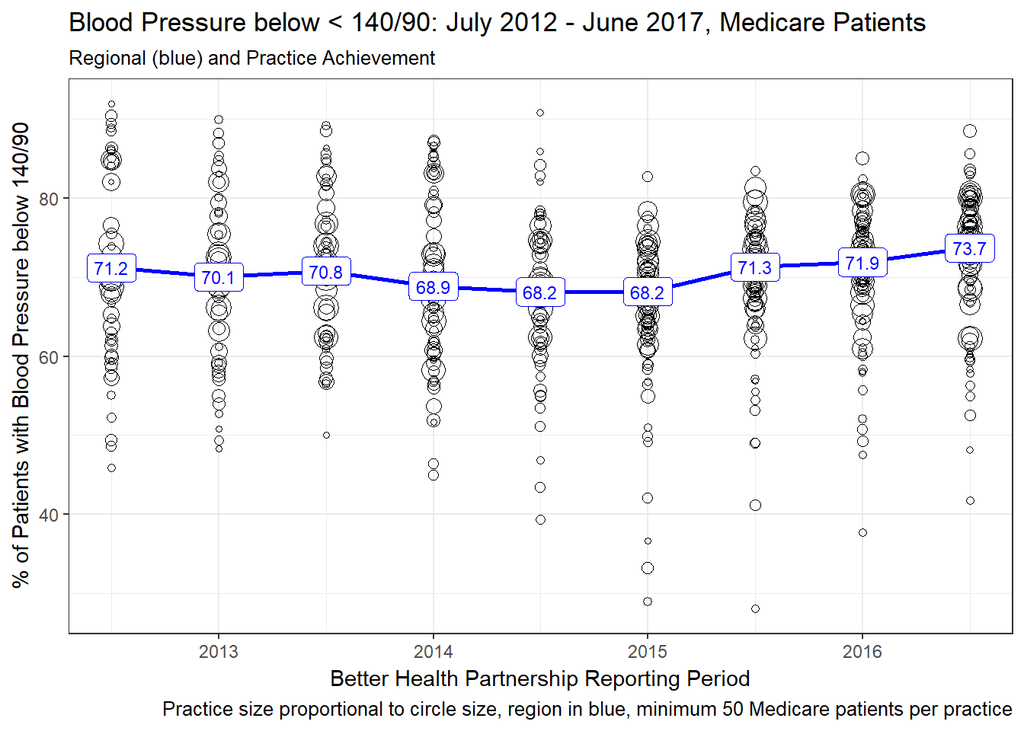

```r
ggplot(data = hbp_medicare, aes(x = time, y = BPLT14090, size = HBPPTS)) +
  geom_point(pch = 1) +
  guides(size = FALSE) +
  geom_line(data = tab_d_medicare, aes(x = time, y = Pct_below_14090),
            col = "blue", size = 1) +
  geom_label(data = tab_d_medicare, aes(x = time, y = Pct_below_14090,
                                  label = decim(Pct_below_14090,1)),
             col = "blue", size = 3) +
  theme_bw() +
  labs(x = "Better Health Partnership Reporting Period",
       y = "% of Patients with Blood Pressure below 140/90",
       title = "Blood Pressure below < 140/90: July 2012 - June 2017, Medicare Patients",
       subtitle = "Regional (blue) and Practice Achievement",
       caption = "Practice size proportional to circle size, region in blue, minimum 50 Medicare patients per practice")
```

### 2.2.4 Model 1. No covariates model, assuming linear time effect

```r
mod1_medicare <- hbp_medicare %$%
  lmer(BPLT14090 ~ years + (1 | PRACCODE), weights = HBPPTS)

# summary(mod1_medicare)
# confint(mod1_medicare, method = "Wald")
```

### 2.2.5 Model 2. Time-varying covariate adjusted model, linear time

This model predicts the percentage of patients with BP < 140/90 at a particular moment in time, using time (in years) since 2012-13, accounting for clustering by practice, and weighting by the number of patients, and using as covariates the following values that vary over time:

- % of patients with BMI < 30
- mean age of patients in the practice
- % of patients in the practice who are female
- neighborhood median income estimate (in $1000s)
- neighborhood high school graduation rate estimate
- % of patients who are white
- % of patients who prefer English
- % of patients who live in the Cuyahoga County suburbs
- % of patients who live outside of Cuyahoga County

BUT EXCLUDING the insurance information.

It, too is a weighted linear mixed model.

```r
mod2_medicare <- hbp_medicare %$%
  lmer(BPLT14090 ~ years + BMILT30 + AGE_MEAN +
         FEMALE + incomeK + ED_MEAN + WHITE +
         ENGLISH + CUYNOTCLE + NOTCUYA +
         (1 | PRACCODE), weights = HBPPTS)

# summary(mod2_medicare)
# confint(mod2_medicare, method = "Wald")
```

## 2.3 Models 1 and 2 restricted to Commercial patients

### 2.3.1 Select out the Commercial practice data from 2012-13 and forward, only those practices with at least 50 Commercial patients.

```r
hbp_commercial <- hbpdat %>%
  filter(PRACTICE != "System") %>%
  filter(PRACTICE != "Region") %>%
  filter(SYSTEM != "SNET") %>%
  filter(time >= 2012.5) %>%
  filter(HBPPTS > 49) %>%
  filter(ORDER == 102) %>%
  select(REPORT, time, years, SYSTEM, PRACTICE, PRACCODE, ORDER, category, subgroup,
         HBPPTS, BPLT14090, BMILT30, AGE_MEAN, FEMALE, incomeK, ED_MEAN, WHITE,
         MEDICARE, COMMERCIAL, MEDICAID, UNINSURED, ENGLISH, SPANISH,
         CLEVE, CUYNOTCLE, NOTCUYA ) %>%
  droplevels()
```

### 2.3.2 Descriptive Summaries (counting only practices with at least 50 Commercial HBP patients)

```r
hbp_commercial <- hbp_commercial %>%
  mutate(n_BPLT14090 = round(HBPPTS * BPLT14090 / 100, 0))

tab_d_commercial <- hbp_commercial %>% group_by(time, years) %>%
  summarize(Practices = n(), Patients = sum(HBPPTS),
            Pct_below_14090 = 100*sum(n_BPLT14090)/sum(HBPPTS))

kable(tab_d_commercial)
```

| time | years | Practices | Patients | Pct_below_14090 |
| --- | --- | --- | --- | --- |
| 2012.5 | 0.0 | 50 | 55406 | 71.30455 |
| 2013.0 | 0.5 | 47 | 54883 | 70.61021 |
| 2013.5 | 1.0 | 47 | 56395 | 71.32015 |
| 2014.0 | 1.5 | 61 | 68775 | 69.51218 |
| 2014.5 | 2.0 | 59 | 70864 | 70.98386 |
| 2015.0 | 2.5 | 65 | 70331 | 67.93448 |
| 2015.5 | 3.0 | 65 | 67664 | 72.21565 |
| 2016.0 | 3.5 | 71 | 65943 | 72.83260 |
| 2016.5 | 4.0 | 74 | 70407 | 74.47839 |

### 2.3.3 Figure 3. Achievement of BP < 140/90, Region-wide, Commercial Patients

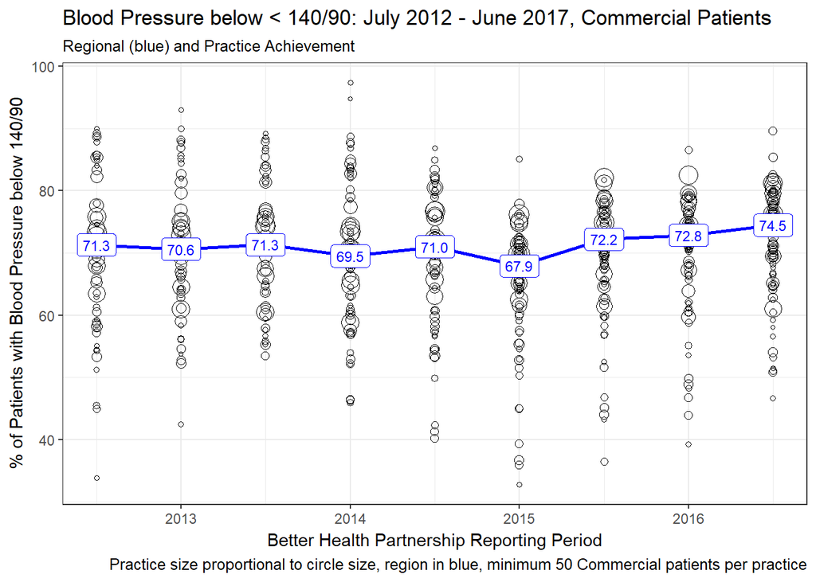

```r
ggplot(data = hbp_commercial, aes(x = time, y = BPLT14090, size = HBPPTS)) +
  geom_point(pch = 1) +
  guides(size = FALSE) +
  geom_line(data = tab_d_commercial, aes(x = time, y = Pct_below_14090),
            col = "blue", size = 1) +
  geom_label(data = tab_d_commercial, aes(x = time, y = Pct_below_14090,
                                  label = decim(Pct_below_14090,1)),
             col = "blue", size = 3) +
  theme_bw() +
  labs(x = "Better Health Partnership Reporting Period",
       y = "% of Patients with Blood Pressure below 140/90",
       title = "Blood Pressure below < 140/90: July 2012 - June 2017, Commercial Patients",
       subtitle = "Regional (blue) and Practice Achievement",
       caption = "Practice size proportional to circle size, region in blue, minimum 50 Commercial patients per practice")
```

### 2.3.4 Model 1. No covariates model, assuming linear time effect

```r
mod1_commercial <- hbp_commercial %$%
  lmer(BPLT14090 ~ years + (1 | PRACCODE), weights = HBPPTS)

# summary(mod1_commercial)
# confint(mod1_commercial, method = "Wald")
```

### 2.3.5 Model 2. Time-varying covariate adjusted model, linear time

This model predicts the percentage of patients with BP < 140/90 at a particular moment in time, using time (in years) since 2012-13, accounting for clustering by practice, and weighting by the number of patients, and using as covariates the following values that vary over time:

- % of patients with BMI < 30
- mean age of patients in the practice
- % of patients in the practice who are female
- neighborhood median income estimate (in $1000s)
- neighborhood high school graduation rate estimate
- % of patients who are white
- % of patients who prefer English
- % of patients who live in the Cuyahoga County suburbs
- % of patients who live outside of Cuyahoga County

BUT EXCLUDING the insurance information.

It, too is a weighted linear mixed model.

```r
mod2_commercial <- hbp_commercial %$%
  lmer(BPLT14090 ~ years + BMILT30 + AGE_MEAN +
         FEMALE + incomeK + ED_MEAN + WHITE +
         ENGLISH + CUYNOTCLE + NOTCUYA +
         (1 | PRACCODE), weights = HBPPTS)

# summary(mod2_commercial)
# confint(mod2_commercial, method = "Wald")
```

## 2.4 Models 1 and 2 restricted to Medicaid patients

### 2.4.1 Select out the Medicaid practice data from 2012-13 and forward, only those practices with at least 50 Medicaid patients.

```r
hbp_medicaid <- hbpdat %>%
  filter(PRACTICE != "System") %>%
  filter(PRACTICE != "Region") %>%
  filter(SYSTEM != "SNET") %>%
  filter(time >= 2012.5) %>%
  filter(HBPPTS > 49) %>%
  filter(ORDER == 103) %>%
  select(REPORT, time, years, SYSTEM, PRACTICE, PRACCODE, ORDER, category, subgroup,
         HBPPTS, BPLT14090, BMILT30, AGE_MEAN, FEMALE, incomeK, ED_MEAN, WHITE,
         MEDICARE, COMMERCIAL, MEDICAID, UNINSURED, ENGLISH, SPANISH,
         CLEVE, CUYNOTCLE, NOTCUYA ) %>%
  droplevels()
```

### 2.4.2 Descriptive Summaries (counting only practices with at least 50 Medicaid HBP patients)

```r
hbp_medicaid <- hbp_medicaid %>%
  mutate(n_BPLT14090 = round(HBPPTS * BPLT14090 / 100, 0))

tab_d_medicaid <- hbp_medicaid %>% group_by(time, years) %>%
  summarize(Practices = n(), Patients = sum(HBPPTS),
            Pct_below_14090 = 100*sum(n_BPLT14090)/sum(HBPPTS))

kable(tab_d_medicaid)
```

| time | years | Practices | Patients | Pct_below_14090 |
| --- | --- | --- | --- | --- |
| 2012.5 | 0.0 | 26 | 10312 | 57.80644 |
| 2013.0 | 0.5 | 26 | 12211 | 57.87405 |
| 2013.5 | 1.0 | 27 | 12896 | 60.22798 |
| 2014.0 | 1.5 | 35 | 14064 | 58.52531 |
| 2014.5 | 2.0 | 42 | 16927 | 61.37532 |
| 2015.0 | 2.5 | 51 | 18455 | 61.08372 |
| 2015.5 | 3.0 | 50 | 17517 | 66.29560 |
| 2016.0 | 3.5 | 52 | 17078 | 70.09603 |
| 2016.5 | 4.0 | 51 | 16615 | 72.97623 |

### 2.4.3 Figure 4. Achievement of BP < 140/90, Region-wide, Medicaid Patients

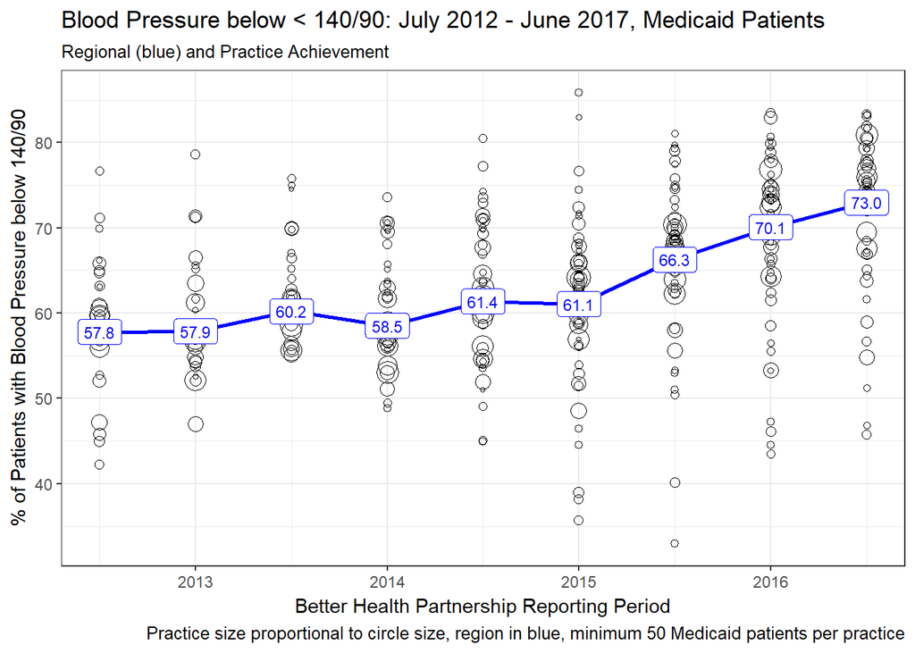

```r
ggplot(data = hbp_medicaid, aes(x = time, y = BPLT14090, size = HBPPTS)) +
  geom_point(pch = 1) +
  guides(size = FALSE) +
  geom_line(data = tab_d_medicaid, aes(x = time, y = Pct_below_14090),
            col = "blue", size = 1) +
  geom_label(data = tab_d_medicaid, aes(x = time, y = Pct_below_14090,
                                  label = decim(Pct_below_14090,1)),
             col = "blue", size = 3) +
  theme_bw() +
  labs(x = "Better Health Partnership Reporting Period",
       y = "% of Patients with Blood Pressure below 140/90",
       title = "Blood Pressure below < 140/90: July 2012 - June 2017, Medicaid Patients",
       subtitle = "Regional (blue) and Practice Achievement",
       caption = "Practice size proportional to circle size, region in blue, minimum 50 Medicaid patients per practice")
```

### 2.4.4 Model 1. No covariates model, assuming linear time effect

```r
mod1_medicaid <- hbp_medicaid %$%
  lmer(BPLT14090 ~ years + (1 | PRACCODE), weights = HBPPTS)

# summary(mod1_medicaid)
# confint(mod1_medicaid, method = "Wald")
```

### 2.4.5 Model 2. Time-varying covariate adjusted model, linear time

This model predicts the percentage of patients with BP < 140/90 at a particular moment in time, using time (in years) since 2012-13, accounting for clustering by practice, and weighting by the number of patients, and using as covariates the following values that vary over time:

- % of patients with BMI < 30
- mean age of patients in the practice
- % of patients in the practice who are female
- neighborhood median income estimate (in $1000s)
- neighborhood high school graduation rate estimate
- % of patients who are white
- % of patients who prefer English
- % of patients who live in the Cuyahoga County suburbs
- % of patients who live outside of Cuyahoga County

BUT EXCLUDING the insurance information.

It, too is a weighted linear mixed model.

```r
mod2_medicaid <- hbp_medicaid %$%
  lmer(BPLT14090 ~ years + BMILT30 + AGE_MEAN +
         FEMALE + incomeK + ED_MEAN + WHITE +
         ENGLISH + CUYNOTCLE + NOTCUYA +
         (1 | PRACCODE), weights = HBPPTS)

# summary(mod2_medicaid)
# confint(mod2_medicaid, method = "Wald")
```

## 2.5 Models 1 and 2 restricted to Uninsured patients

### 2.5.1 Select out the Uninsured practice data from 2012-13 and forward, only those practices with at least 50 Uninsured patients.

```r
hbp_uninsured <- hbpdat %>%
  filter(PRACTICE != "System") %>%
  filter(PRACTICE != "Region") %>%
  filter(SYSTEM != "SNET") %>%
  filter(time >= 2012.5) %>%
  filter(HBPPTS > 49) %>%
  filter(ORDER == 104) %>%
  select(REPORT, time, years, SYSTEM, PRACTICE, PRACCODE, ORDER, category, subgroup,
         HBPPTS, BPLT14090, BMILT30, AGE_MEAN, FEMALE, incomeK, ED_MEAN, WHITE,
         MEDICARE, COMMERCIAL, MEDICAID, UNINSURED, ENGLISH, SPANISH,
         CLEVE, CUYNOTCLE, NOTCUYA ) %>%
  droplevels()
```

### 2.5.2 Descriptive Summaries (counting only practices with at least 50 Uninsured HBP patients)

```r
hbp_uninsured <- hbp_uninsured %>%
  mutate(n_BPLT14090 = round(HBPPTS * BPLT14090 / 100, 0))

tab_d_uninsured <- hbp_uninsured %>% group_by(time, years) %>%
  summarize(Practices = n(), Patients = sum(HBPPTS),
            Pct_below_14090 = 100*sum(n_BPLT14090)/sum(HBPPTS))

kable(tab_d_uninsured)
```

| time | years | Practices | Patients | Pct_below_14090 |
| --- | --- | --- | --- | --- |
| 2012.5 | 0.0 | 35 | 9838 | 53.87274 |
| 2013.0 | 0.5 | 30 | 6529 | 59.71818 |
| 2013.5 | 1.0 | 29 | 5591 | 60.68682 |
| 2014.0 | 1.5 | 28 | 4382 | 59.97262 |
| 2014.5 | 2.0 | 28 | 3973 | 63.50365 |
| 2015.0 | 2.5 | 28 | 3631 | 61.80116 |
| 2015.5 | 3.0 | 25 | 3138 | 66.57106 |
| 2016.0 | 3.5 | 27 | 3156 | 69.35995 |
| 2016.5 | 4.0 | 31 | 3548 | 69.27847 |

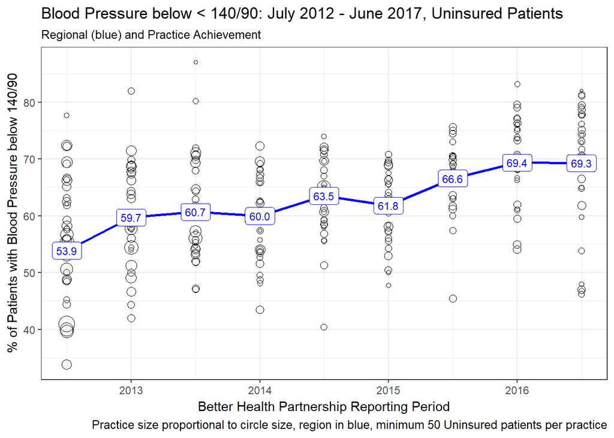

```r
ggplot(data = hbp_uninsured, aes(x = time, y = BPLT14090, size = HBPPTS)) +
  geom_point(pch = 1) +
  guides(size = FALSE) +
  geom_line(data = tab_d_uninsured, aes(x = time, y = Pct_below_14090),
            col = "blue", size = 1) +
  geom_label(data = tab_d_uninsured, aes(x = time, y = Pct_below_14090,
                                  label = decim(Pct_below_14090,1)),
             col = "blue", size = 3) +
  theme_bw() +
  labs(x = "Better Health Partnership Reporting Period",
       y = "% of Patients with Blood Pressure below 140/90",
       title = "Blood Pressure below < 140/90: July 2012 - June 2017, Uninsured Patients",
       subtitle = "Regional (blue) and Practice Achievement",
       caption = "Practice size proportional to circle size, region in blue, minimum 50 Uninsured patients per practice")
```

### 2.5.4 Model 1. No covariates model, assuming linear time effect

```r
mod1_uninsured <- hbp_uninsured %$%
  lmer(BPLT14090 ~ years + (1 | PRACCODE), weights = HBPPTS)

# summary(mod1_uninsured)
# confint(mod1_uninsured, method = "Wald")
```

### 2.5.5 Model 2. Time-varying covariate adjusted model, linear time

This model predicts the percentage of patients with BP < 140/90 at a particular moment in time, using time (in years) since 2012-13, accounting for clustering by practice, and weighting by the number of patients, and using as covariates the following values that vary over time:

- % of patients with BMI < 30
- mean age of patients in the practice
- % of patients in the practice who are female
- neighborhood median income estimate (in $1000s)
- neighborhood high school graduation rate estimate
- % of patients who are white
- % of patients who prefer English
- % of patients who live in the Cuyahoga County suburbs
- % of patients who live outside of Cuyahoga County

BUT EXCLUDING the insurance information.

It, too is a weighted linear mixed model.

```r
mod2_uninsured <- hbp_uninsured %$%
  lmer(BPLT14090 ~ years + BMILT30 + AGE_MEAN +
         FEMALE + incomeK + ED_MEAN + WHITE +
         ENGLISH + CUYNOTCLE + NOTCUYA +
         (1 | PRACCODE), weights = HBPPTS)

# summary(mod2_uninsured)
# confint(mod2_uninsured, method = "Wald")
```

## 2.6 Results for Models 1 and 2

### 2.6.1 Build the data set of results

```r
res12 <- data.frame(
  model = rep(c(1, 2)),
  subgroup = c(rep("All Patients", 2), rep("Medicare", 2), rep("Commercial", 2),
               rep("Medicaid",2), rep("Uninsured",2)),
  estimate = c(filter(tidy(mod1_overall), term == "years")$estimate,
               filter(tidy(mod2_overall), term == "years")$estimate,
               filter(tidy(mod1_medicare), term == "years")$estimate,
               filter(tidy(mod2_medicare), term == "years")$estimate,
               filter(tidy(mod1_commercial), term == "years")$estimate,
               filter(tidy(mod2_commercial), term == "years")$estimate,
               filter(tidy(mod1_medicaid), term == "years")$estimate,
               filter(tidy(mod2_medicaid), term == "years")$estimate,
               filter(tidy(mod1_uninsured), term == "years")$estimate,
               filter(tidy(mod2_uninsured), term == "years")$estimate),
  std.err = c(filter(tidy(mod1_overall), term == "years")$std.err,
              filter(tidy(mod2_overall), term == "years")$std.err,
              filter(tidy(mod1_medicare), term == "years")$std.err,
              filter(tidy(mod2_medicare), term == "years")$std.err,
              filter(tidy(mod1_commercial), term == "years")$std.err,
              filter(tidy(mod2_commercial), term == "years")$std.err,
              filter(tidy(mod1_medicaid), term == "years")$std.err,
              filter(tidy(mod2_medicaid), term == "years")$std.err,
              filter(tidy(mod1_uninsured), term == "years")$std.err,
              filter(tidy(mod2_uninsured), term == "years")$std.err),
  low.95ci = c(confint(mod1_overall, method = "Wald")["years",1],
               confint(mod2_overall, method = "Wald")["years",1],
               confint(mod1_medicare, method = "Wald")["years",1],
               confint(mod2_medicare, method = "Wald")["years",1],
               confint(mod1_commercial, method = "Wald")["years",1],
               confint(mod2_commercial, method = "Wald")["years",1],
               confint(mod1_medicaid, method = "Wald")["years",1],
               confint(mod2_medicaid, method = "Wald")["years",1],
               confint(mod1_uninsured, method = "Wald")["years",1],
               confint(mod2_uninsured, method = "Wald")["years",1]),
    hi.95ci = c(confint(mod1_overall, method = "Wald")["years",2],
              confint(mod2_overall, method = "Wald")["years",2],
              confint(mod1_medicare, method = "Wald")["years",2],
              confint(mod2_medicare, method = "Wald")["years",2],
              confint(mod1_commercial, method = "Wald")["years",2],
              confint(mod2_commercial, method = "Wald")["years",2],
              confint(mod1_medicaid, method = "Wald")["years",2],
              confint(mod2_medicaid, method = "Wald")["years",2],
              confint(mod1_uninsured, method = "Wald")["years",2],
              confint(mod2_uninsured, method = "Wald")["years",2])
  )
```

## 2.7 Table of Results So Far

```r
res12
```

| model | subgroup | estimate | std.err | low.95ci | hi.95ci |
| --- | --- | --- | --- | --- | --- |
| 1 | All Patients | 1.974134 | 0.1283022 | 1.722667 | 2.225602 |
| 2 | All Patients | 2.250948 | 0.1643192 | 1.928889 | 2.573008 |
| 1 | Medicare | 1.749791 | 0.1374366 | 1.480420 | 2.019161 |
| 2 | Medicare | 2.084670 | 0.1560848 | 1.778749 | 2.390590 |
| 1 | Commercial | 1.650727 | 0.1339746 | 1.388141 | 1.913312 |
| 2 | Commercial | 2.518696 | 0.1841209 | 2.157825 | 2.879566 |
| 1 | Medicaid | 3.850472 | 0.2064491 | 3.445839 | 4.255105 |
| 2 | Medicaid | 4.919258 | 0.2327696 | 4.463038 | 5.375478 |
| 1 | Uninsured | 2.760025 | 0.2325529 | 2.304230 | 3.215821 |
| 2 | Uninsured | 3.418286 | 0.2995596 | 2.831160 | 4.005412 |

## 2.8 Figure 6. Graph of Results So Far (Model 1: No Covariates)

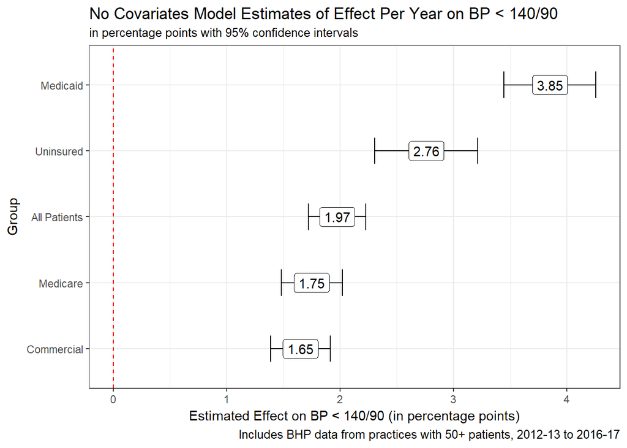

```r
fig_model1 <- res12 %>% filter(model == 1)

fig_model1$subgroup <- fct_reorder(fig_model1$subgroup, fig_model1$estimate)

ggplot(fig_model1, aes(x = estimate, y = subgroup, label = decim(estimate, 2))) +
  geom_vline(xintercept = 0, lty = "dashed", col = "red") +
  geom_errorbarh(aes(xmax = hi.95ci, xmin = low.95ci, height = 0.4)) +
  geom_label() +
  theme_bw() +
  labs(x = "Estimated Effect on BP < 140/90 (in percentage points)",
       y = "Group",
       title = "No Covariates Model Estimates of Effect Per Year on BP < 140/90",
       subtitle = "in percentage points with 95% confidence intervals",
       caption = "Includes BHP data from practices with 50+ patients, 2012-13 to 2016-17")
```

## 2.9 Figure 7. Graph of Results So Far (Model 2: Time-Varying Covariates)

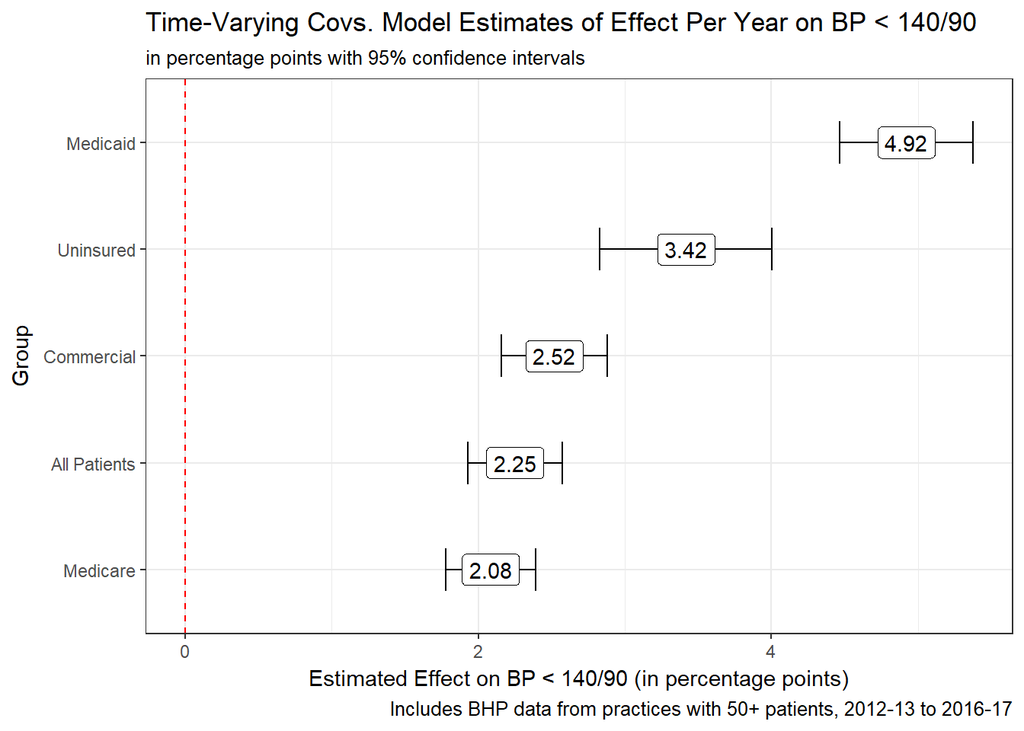

```r
fig_model2 <- res12 %>% filter(model == 2)

fig_model2$subgroup <- fct_reorder(fig_model2$subgroup, fig_model2$estimate)

ggplot(fig_model2, aes(x = estimate, y = subgroup, label = decim(estimate, 2))) +
  geom_vline(xintercept = 0, lty = "dashed", col = "red") +
  geom_errorbarh(aes(xmax = hi.95ci, xmin = low.95ci, height = 0.4)) +
  geom_label() +
  theme_bw() +
  labs(x = "Estimated Effect on BP < 140/90 (in percentage points)",
       y = "Group",
       title = "Time-Varying Covs. Model Estimates of Effect Per Year on BP < 140/90",
       subtitle = "in percentage points with 95% confidence intervals",
       caption = "Includes BHP data from practices with 50+ patients, 2012-13 to 2016-17")
```

# 3 Analysis 3

The goal here is to take the same approach as in Analysis 1 (the Model 1 and Model 2 for the Overall group - All Patients), but restricted to practices in the (a) Low (b) Middle and (c) High exposure groups.

## 3.1 Note to Rujia / Steven

I am hoping you will:

1. Add the “Low”, “Moderate” and “High” information back into the hbpdat file down here in the Analysis 3 section.
2. Develop pictures like I have done in Figures 1-5 (using Figure 1 as the model) for the Low group, then for the Moderate group and then for the High group across all patients.
3. Use my code in the `Across All Patients (Overall subgroup)` section as the basis for modeling, and produce a model for Low, a model for Moderate, and a model for High.
4. Gather the results of the models into a data set, as I have done for the overall and insurance information above in the Results for Models 1 and 2 section.

Thanks!

```
 setting  value
 version  R version 3.4.3 (2017-11-30)
 system   x86_64, mingw32
 ui       RTerm
 language (EN)
 collate  English_United States.1252
 tz       America/New_York
 date     2017-12-06
```

```
Packages -----------------------------------------------------------------
```

```
 package    * version date       source
 assertthat   0.2.0   2017-04-11 CRAN (R 3.4.0)
 backports    1.1.1   2017-09-25 CRAN (R 3.4.1)
 base       * 3.4.3   2017-11-30 local
 bindr        0.1     2016-11-13 CRAN (R 3.4.0)
 bindrcpp   * 0.2     2017-06-17 CRAN (R 3.4.0)
 broom      * 0.4.3   2017-11-20 CRAN (R 3.4.2)
 cellranger   1.1.0   2016-07-27 CRAN (R 3.4.0)
 cli          1.0.0   2017-11-05 CRAN (R 3.4.2)
 colorspace   1.3-2   2016-12-14 CRAN (R 3.4.0)
 compiler     3.4.3   2017-11-30 local
 crayon       1.3.4   2017-09-16 CRAN (R 3.4.1)
 datasets   * 3.4.3   2017-11-30 local
 devtools     1.13.4  2017-11-09 CRAN (R 3.4.2)
 digest       0.6.12  2017-01-27 CRAN (R 3.4.0)
 dplyr      * 0.7.4   2017-09-28 CRAN (R 3.4.2)
 evaluate     0.10.1  2017-06-24 CRAN (R 3.4.0)
 forcats    * 0.2.0   2017-01-23 CRAN (R 3.4.2)
 foreign      0.8-69  2017-06-21 CRAN (R 3.4.1)
 ggplot2    * 2.2.1   2016-12-30 CRAN (R 3.4.0)
 glue         1.2.0   2017-10-29 CRAN (R 3.4.2)
 graphics   * 3.4.3   2017-11-30 local
 grDevices  * 3.4.3   2017-11-30 local
 grid         3.4.3   2017-11-30 local
 gtable       0.2.0   2016-02-26 CRAN (R 3.4.0)
 haven        1.1.0   2017-07-09 CRAN (R 3.4.1)
 highr        0.6     2016-05-09 CRAN (R 3.4.0)
 hms          0.4.0   2017-11-23 CRAN (R 3.4.2)
 htmltools    0.3.6   2017-04-28 CRAN (R 3.4.0)
 httr         1.3.1   2017-08-20 CRAN (R 3.4.1)
 jsonlite     1.5     2017-06-01 CRAN (R 3.4.0)
 knitr      * 1.17    2017-08-10 CRAN (R 3.4.3)
 labeling     0.3     2014-08-23 CRAN (R 3.4.0)
 lattice      0.20-35 2017-03-25 CRAN (R 3.4.3)
 lazyeval     0.2.1   2017-10-29 CRAN (R 3.4.2)
 lme4       * 1.1-14  2017-09-27 CRAN (R 3.4.2)
 lubridate    1.7.1   2017-11-03 CRAN (R 3.4.2)
 magrittr   * 1.5     2014-11-22 CRAN (R 3.4.1)
 MASS         7.3-47  2017-04-21 CRAN (R 3.4.2)
 Matrix     * 1.2-12  2017-11-20 CRAN (R 3.4.3)
```

[output cut: 21 more lines]

```
 rstudioapi   0.7     2017-09-07 CRAN (R 3.4.1)
 rvest        0.3.2   2016-06-17 CRAN (R 3.4.0)
 scales       0.5.0   2017-08-24 CRAN (R 3.4.1)
 splines      3.4.3   2017-11-30 local
 stats      * 3.4.3   2017-11-30 local
 stringi      1.1.6   2017-11-17 CRAN (R 3.4.2)
 stringr    * 1.2.0   2017-02-18 CRAN (R 3.4.0)
 tibble     * 1.3.4   2017-08-22 CRAN (R 3.4.1)
 tidyr      * 0.7.2   2017-10-16 CRAN (R 3.4.2)
 tidyverse  * 1.2.1   2017-11-14 CRAN (R 3.4.2)
 tools        3.4.3   2017-11-30 local
 utils      * 3.4.3   2017-11-30 local
 withr        2.1.0   2017-11-01 CRAN (R 3.4.2)
 xml2         1.1.1   2017-01-24 CRAN (R 3.4.0)
 yaml         2.1.15  2017-12-01 CRAN (R 3.4.3)
```